# Topic 16

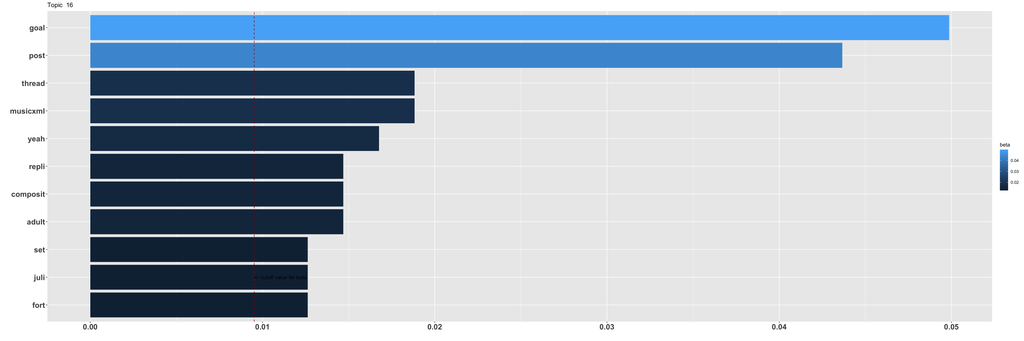

On interpreting beta: the term has a beta probability of being generated from the particular topic.

Values below are gamma : An estimated proportion of words from that document that are generated from that topic.

**Text Record Number: 1442** gamma: 35 % likelihood of this document (based on its words) in this topic

Every month, we run a practice “contest” for fun to encourage people to meet their practice goals.

# This Month’s Goal & How to Sign Up and Track

Let’s make July a personal goal month. If you’d like to participate, simply comment in this thread and say the total number of hours you will practice between July 1st and July 31st.

Log your time using [www.tuneupgrade.com](https://www.tuneupgrade.com/) (you can use the time tracking or just navigate to the ‘log’ tab and enter your time manually). I’ll pull updates once a week on Sundays and post a new sticky thread with the latest numbers. If your reddit username and tuneupgrade usernames are different, let me know in the thread below.

If you need help or want a quick overview, this [youtube video](https://www.youtube.com/watch?v=jS-dzpt1tQg) will walk you through how to get set up.

# What do you win?

Anyone who participated can request a custom flair if we make the community goal for the month.

# This is a great community - thank you for participating!

I’ve been really impressed with the amount of time and effort people put in to practice. If you ever feel like you’re not making progress as you should, always feel free to post threads to get feedback on routines, post your learning progress in videos, and hear from the community.

# June Results

Below are the results for June! If you made your goal, comment in the thread if you want a custom flair.

| Username | Goal | Hours Practiced |
| --- | --- | --- |
| /u/viperscorpio | 20 | 18.4 |
| /u/I_P_L | 40 | 64.4 |
| /u/darkByt31 | 20 | 4.5 |
| /u/fabianom7 | 20 | 41.9 |
| /u/lins05 | 10 | 2.2 |
| /u/midgardsormr1982 | 10 | 21.0 |
| /u/ElectronicProgram | 20 | 21.5 |
| /u/xRedSoL | 30 | 31.0 |